# Assignment 10

Nhu Ho

2025-06-01

## 1. Load and Inspect the Data

```r
data <- read_excel("/Users/hoangnhu/Downloads/metaanalysis_data.xlsx")
head(data)
```

```
## # A tibble: 6 × 28
##   Study            `Female authors` `Male authors` `Age (months)` N_boys N_girls
##   <chr>                       <dbl>          <dbl>          <dbl>  <dbl>   <dbl>
## 1 Alexander & Sae…                2              0           19.5     47      47
## 2 Arthur (2014)                   1              0           19       22      18
## 3 Berenbaum & Hin…                2              0           65.8     18      18
## 4 Berenbaum & Sny…                2              0           93.1     19      19
## 5 Doering et al (…                1              3           87       15      15
## 6 Idle et al. (19…                2              1           46       10      10
## # ℹ 22 more variables: Mean_boys_play_male <dbl>, SD_boys_play_male <dbl>,
## #   Mean_girls_play_male <dbl>, SD_girls_play_male <dbl>,
## #   Mean_boys_play_female <dbl>, SD_boys_play_female <dbl>,
## #   Mean_girls_play_female <dbl>, SD_girls_play_female <dbl>,
## #   `Neutral toys` <dbl>, Year <dbl>, `Parent present` <dbl>, Setting <dbl>,
## #   Country <dbl>, `Case definition adequate` <chr>,
## #   `Representativeness of cases` <chr>, `Selection of controls` <chr>, …
```

```r
str(data)
```

```
## tibble [27 × 28] (S3: tbl_df/tbl/data.frame)
##  $ Study                                    : chr [1:27] "Alexander & Saenz (2012)" "Arthur (2014)" "Berenbaum & Hines (1992)" "Berenbaum & Snyder (1995)" ...
##  $ Female authors                           : num [1:27] 2 1 2 2 1 2 5 2 3 3 ...
##  $ Male authors                             : num [1:27] 0 0 0 0 3 1 1 0 3 3 ...
##  $ Age (months)                             : num [1:27] 19.5 19 65.8 93.1 87 ...
##  $ N_boys                                   : num [1:27] 47 22 18 19 15 10 21 38 12 25 ...
##  $ N_girls                                  : num [1:27] 47 18 18 19 15 10 21 38 12 25 ...
##  $ Mean_boys_play_male                      : num [1:27] 439 148 325 484 260 ...
##  $ SD_boys_play_male                        : num [1:27] 166.1 105 270.2 141.3 67.7 ...
##  $ Mean_girls_play_male                     : num [1:27] 248.6 54 135.1 202.5 98.4 ...
##  $ SD_girls_play_male                       : num [1:27] 161 53 202 168 101 ...
##  $ Mean_boys_play_female                    : num [1:27] 377.3 126 33.5 26.4 7.2 ...
##  $ SD_boys_play_female                      : num [1:27] 170.9 67 69.5 92 21.5 ...
##  $ Mean_girls_play_female                   : num [1:27] 539 244 248 265 145 ...
##  $ SD_girls_play_female                     : num [1:27] 214 54 246 241 110 ...
##  $ Neutral toys                             : num [1:27] 1 0 1 1 1 1 1 1 1 1 ...
##  $ Year                                     : num [1:27] 2012 2014 1992 1995 1989 ...
##  $ Parent present                           : num [1:27] 3 2 2 2 1 3 2 1 3 3 ...
##  $ Setting                                  : num [1:27] 2 2 2 1 2 3 2 1 2 2 ...
##  $ Country                                  : num [1:27] 0.256 0.28 0.252 0.252 0.141 0.141 0.248 NA 0.228 0.228 ...
##  $ Case definition adequate                 : chr [1:27] "*" "*" "X" "*" ...
##  $ Representativeness of cases              : chr [1:27] "*" "X" "*" "X" ...
##  $ Selection of controls                    : chr [1:27] "X" "X" "*" "*" ...
##  $ Parental opinion                         : chr [1:27] "X" "X" "*" "*" ...
##  $ Comparability of both groups             : chr [1:27] "*" "**" "*" "*" ...
##  $ Ascertainment of behaviour               : chr [1:27] "*" "*" "*" "*" ...
##  $ Same ascertainment method for both groups: chr [1:27] "*" "*" "*" "*" ...
##  $ Non‐response rate                        : chr [1:27] "X" "*" "X" "*" ...
##  $ NOS score                                : num [1:27] 5 6 6 7 6 8 7 6 7 7 ...
```

## 2. Meta-analysis: Calculating Effect Sizes

I assume boys are the experimental group and girls the control group.

```r
m <- metacont(n.e = data$N_boys,
                   mean.e = data$Mean_boys_play_male,
                   sd.e = data$SD_boys_play_male,
                   n.c = data$N_girls,
                   mean.c = data$Mean_girls_play_male,
                   sd.c = data$SD_girls_play_male,
                   data = data,
                   studlab = data$Study,
                   common = TRUE,
                   random = TRUE)
summary(m)
```

```
##                                            MD               95%-CI %W(common)
## Alexander & Saenz (2012)             190.0800 [123.8955; 256.2645]        0.7
## Arthur (2014)                         94.0000 [ 43.7548; 144.2452]        1.2
## Berenbaum & Hines (1992)             190.1200 [ 34.3440; 345.8960]        0.1
## Berenbaum & Snyder (1995)            281.7300 [182.9805; 380.4795]        0.3
## Doering et al (1989)                 161.7000 [100.0416; 223.3584]        0.8
## Idle et al. (1993)                   122.0000 [  1.0740; 242.9260]        0.2
## Lamminmäki & Hines (2012)             12.6600 [-19.8693;  45.1893]        2.9
## Li & Wong (2016)                     171.3200 [121.1964; 221.4436]        1.2
## Pasterski et al. (2005)              237.6000 [169.8918; 305.3082]        0.7
## Pasterski et al. (2005)              100.8000 [ 31.0789; 170.5211]        0.6
## Pasterski et al. (2005)              205.2000 [150.1672; 260.2328]        1.0
## Schau et al. (1980)                  225.5600 [135.1433; 315.9767]        0.4
## Servin et al. (1999)                  67.8100 [ 10.1755; 125.4445]        0.9
## Servin et al. (1999)                 140.1300 [ 84.4291; 195.8309]        1.0
## Servin et al. (1999)                  93.6500 [  8.9695; 178.3305]        0.4
## Todd et al. (2016)                    25.9000 [ 12.1584;  39.6416]       16.5
## Todd et al. (2016)                    34.6500 [ 18.6896;  50.6104]       12.2
## Todd et al. (2016)                    61.4000 [ 44.9453;  77.8547]       11.5
## van de Beek (2009)                    57.5100 [ 20.1292;  94.8908]        2.2
## Wilansky-Traynor & Lobel (2008)       77.8800 [ 37.6882; 118.0718]        1.9
## Wilansky-Traynor & Lobel (2008)       48.8800 [  7.6239;  90.1361]        1.8
## Zosuls et al. (2009)                  42.0000 [ 10.3358;  73.6642]        3.1
## Zosuls et al. (2009)                  48.0000 [  8.3138;  87.6862]        2.0
## Zosuls et al. (2009)                  12.0000 [-20.6203;  44.6203]        2.9
## Zosuls et al. (2009)                  30.0000 [ -4.8962;  64.8962]        2.6
## Zosuls, Ruble & Tamis-LeMonda (2014)  32.4000 [ 18.9613;  45.8387]       17.3
## Zosuls, Ruble & Tamis-LeMonda (2014)  24.3000 [  8.9011;  39.6989]       13.2
##                                      %W(random)
## Alexander & Saenz (2012)                    3.5
## Arthur (2014)                               3.8
## Berenbaum & Hines (1992)                    1.9
## Berenbaum & Snyder (1995)                   2.8
## Doering et al (1989)                        3.6
## Idle et al. (1993)                          2.4
## Lamminmäki & Hines (2012)                   4.1
## Li & Wong (2016)                            3.8
## Pasterski et al. (2005)                     3.5
## Pasterski et al. (2005)                     3.4
## Pasterski et al. (2005)                     3.7
```

[output cut: 22 more lines]

```
## Random effects model 94.7832 [66.7897; 122.7766]  6.64 < 0.0001
##
## Quantifying heterogeneity (with 95%-CIs):
##  tau^2 = 4678.7733 [2666.5809; 10251.8327]; tau = 68.4016 [51.6389; 101.2513]
##  I^2 = 88.0% [83.7%; 91.1%]; H = 2.88 [2.48; 3.36]
##
## Test of heterogeneity:
##       Q d.f.  p-value
##  216.00   26 < 0.0001
##
## Details of meta-analysis methods:
## - Inverse variance method
## - Restricted maximum-likelihood estimator for tau^2
## - Q-Profile method for confidence interval of tau^2 and tau
## - Calculation of I^2 based on Q
```

## 3. Forest Plot

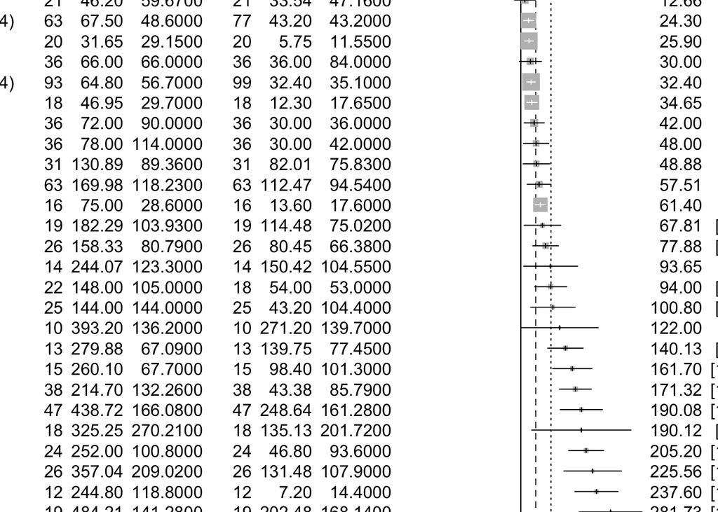

```r
m %>% forest(sortvar=TE)
```

## 4. Funnel Plot (Basic)

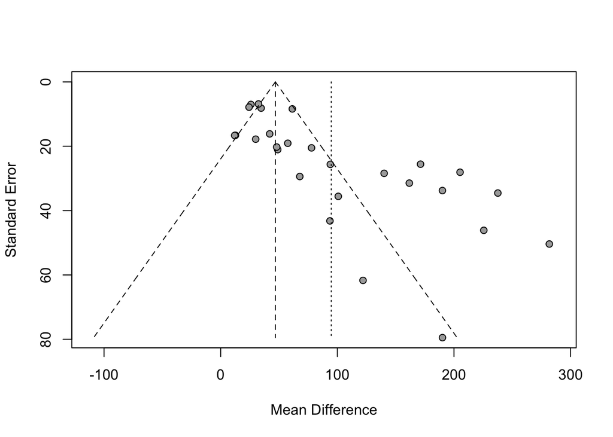

```r
m %>% funnel()
```

## 5. Funnel Plot (Contour-enhanced)

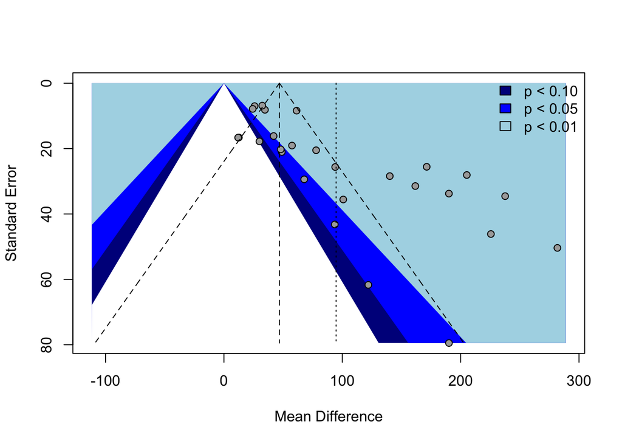

```r
contour_levels <- c(0.90, 0.95, 0.99)
contour_colors <- c("darkblue", "blue", "lightblue")
funnel(m, contour = contour_levels, col.contour = contour_colors)
legend("topright", c("p < 0.10", "p < 0.05", "p < 0.01"), bty = "n", fill = contour_colors)
```

## 6. Meta-regression: Does Method or Quality Affect Results?

```r
# Replace these with correct variable names from your dataset
m %>% metareg(~ `Neutral toys` + `Parent present` + Setting + `NOS score`)
```

```
##
## Mixed-Effects Model (k = 27; tau^2 estimator: REML)
##
## tau^2 (estimated amount of residual heterogeneity):     3617.1210 (SE = 1313.1269)
## tau (square root of estimated tau^2 value):             60.1425
## I^2 (residual heterogeneity / unaccounted variability): 93.46%
## H^2 (unaccounted variability / sampling variability):   15.28
## R^2 (amount of heterogeneity accounted for):            22.69%
##
## Test for Residual Heterogeneity:
## QE(df = 22) = 172.6977, p-val < .0001
##
## Test of Moderators (coefficients 2:5):
## QM(df = 4) = 10.1240, p-val = 0.0384
##
## Model Results:
##
##                   estimate        se     zval    pval     ci.lb     ci.ub
## intrcpt           341.2893  151.5468   2.2520  0.0243   44.2630  638.3155  *
## `Neutral toys`    102.6731   44.6994   2.2970  0.0216   15.0638  190.2823  *
## `Parent present`  -10.6181   20.6764  -0.5135  0.6076  -51.1432   29.9069
## Setting            28.6715   27.2195   1.0533  0.2922  -24.6777   82.0207
## `NOS score`       -53.2151   22.0037  -2.4185  0.0156  -96.3416  -10.0885  *
##
## ---
## Signif. codes:  0 '***' 0.001 '**' 0.01 '*' 0.05 '.' 0.1 ' ' 1
```

## 7. Meta-regression: Does Author Gender Affect the Results?

```r
m$data$Author_gender_ratio <- m$data$`Female authors` /
  (m$data$`Female authors` + m$data$`Male authors`)

m %>% metareg(~ Author_gender_ratio)
```

```
##
## Mixed-Effects Model (k = 27; tau^2 estimator: REML)
##
## tau^2 (estimated amount of residual heterogeneity):     4875.3226 (SE = 1596.7062)
## tau (square root of estimated tau^2 value):             69.8235
## I^2 (residual heterogeneity / unaccounted variability): 95.00%
## H^2 (unaccounted variability / sampling variability):   19.99
## R^2 (amount of heterogeneity accounted for):            0.00%
##
## Test for Residual Heterogeneity:
## QE(df = 25) = 213.1237, p-val < .0001
##
## Test of Moderators (coefficient 2):
## QM(df = 1) = 0.1087, p-val = 0.7416
##
## Model Results:
##
##                      estimate       se     zval    pval      ci.lb     ci.ub
## intrcpt              113.2136  57.0022   1.9861  0.0470     1.4913  224.9358  *
## Author_gender_ratio  -23.0097  69.7756  -0.3298  0.7416  -159.7674  113.7479
##
## ---
## Signif. codes:  0 '***' 0.001 '**' 0.01 '*' 0.05 '.' 0.1 ' ' 1
```

## 8. Interpretation

- Combined Effects:
  - The combined result using a random-effects model showed a statistically significant difference (MD = 94.78, p < 0.0001), with boys exhibiting higher play behavior scores.
  - There was very high heterogeneity among the studies (I^2 = 88.0%).
- Forest Plot:
  - The forest plot shows the Mean Difference (MD) for each study and the overall combined result. It illustrates considerable variation in results across individual studies.
- Funnel Plot:
  - The funnel plot showed asymmetry, suggesting potential publication bias or other factors contributing to heterogeneity. Studies appeared to be more concentrated on the side with positive and statistically significant results.
- Meta-regression: Effect of Methods/Quality:
  - Study methodology and quality factors (NOS score) explained a portion of the heterogeneity (approximately 22.69%).
  - Specifically, the presence of Neutral toys and the NOS score (study quality score) significantly influenced the results.
- Meta-regression: Effect of Author Gender:
  - The gender ratio of authors did not significantly affect the study results (p = 0.7416).

## References

- Using the assignment 10 of teacher’s code
- Using ChatGPT to fix my error code for part 7